# Introduction to mrgsolve

PAGE 2018 Workshop

Metrum Research Group, LLC

# People

- Michelle Johnson
- Matthew Riggs
- Bill Knebel
- Kyle Baron
- The participants … thank you for coming!

# Cloud-based computer access via Metworx

- Each participant may access an 8 core cloud instance using Metworx
- All software (R packages) needed for the workshop is pre-installed
- We will use Rstudio and the R package mrgsolve for the course exercises
- System requirements: Laptop with wifi and a browser

# Accessing Metworx

### https://metworx-eu-central-stage.metworx.com

### Sign in to Metworx username: page2018-n@metrumrg.com password PageConf2018! Sign in to Rstudio Click on Rstudio username: page2018 password: PageConf2018!

# Check out the repo

```r
username <- "mrgsolve-sp18"
password <- "a45f7aa3d8f8fa53b25d2db780f6077ccba80925"

#############################

.libPaths("/data/page-Rlibs")

if(!require("git2r")) install.packages("git2r")

library(git2r)

.repo_addr <- "https://github.com/metrumresearchgroup/page-2018-mrgsolve"
.where <- "page-2018-mrgsolve-workshop"
.branch <- "master"

if(!file.exists(.where)) dir.create(.where)

repo <- clone(
  .repo_addr,
  branch=.branch,
  credentials=cred_user_pass(username,password),
  local_path=.where
)
```

# Why “Open Science”?

- What is this concept of “open” ?
- How & why is it beneficial to the growth of our community
- Examples:
  - open-source software: SBML, mrgsolve, Shiny etc., STAN/Torsten(?)
  - open model repositories: Biomodels, github, DDmore. . .
  - Publications, presentations, regulatory docs:
    - good (model is described with parameter estimates),
    - better (model mathematics provided with parameter estimates),
    - best (executable code)
  - PKsim / MOBI
  - Osmosis Foundation

# How we implement our science

- Overview of Metworx system
  - why share when you don’t have to (Performance),
  - how to easily share when you want to (Envision)

# Ideal computing

[figure not shown]

# What we might want

[figure not shown]

# Our workflow (Metworx)

[figure not shown]

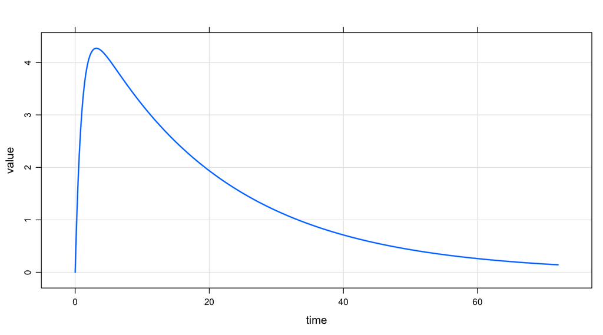

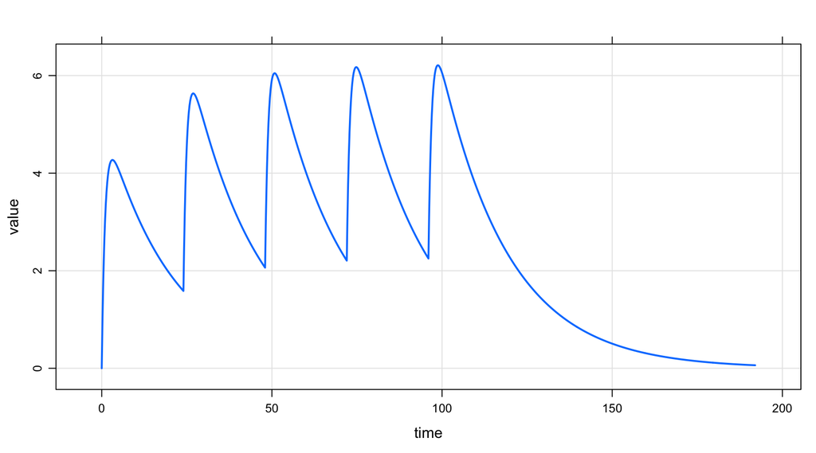

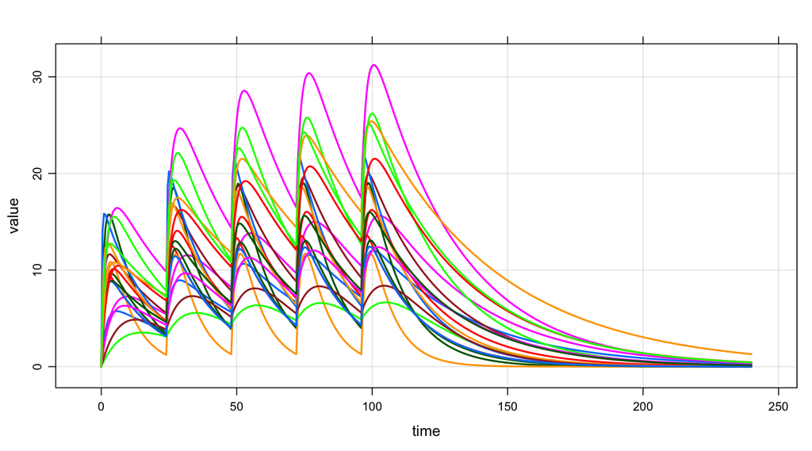

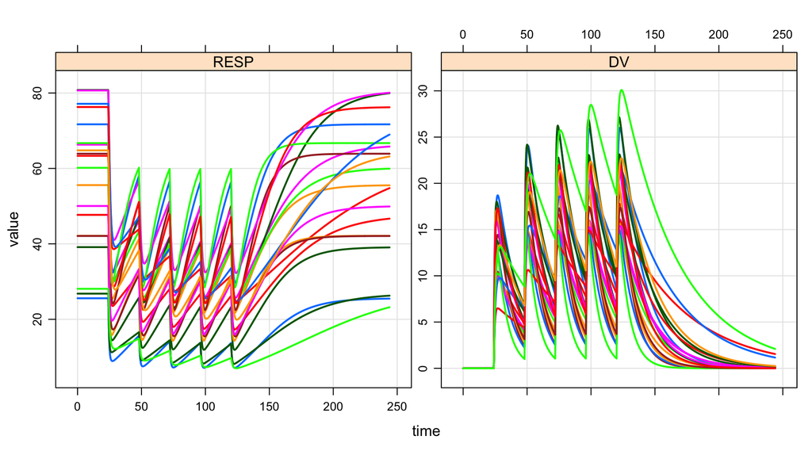

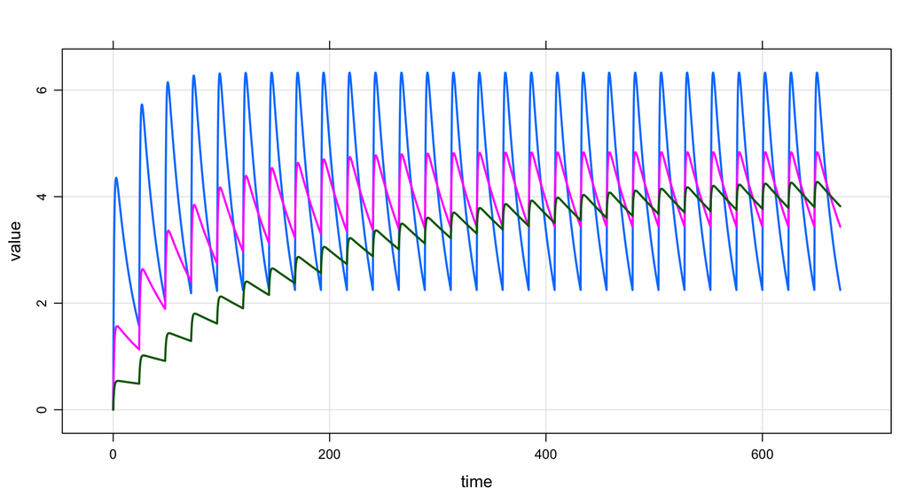

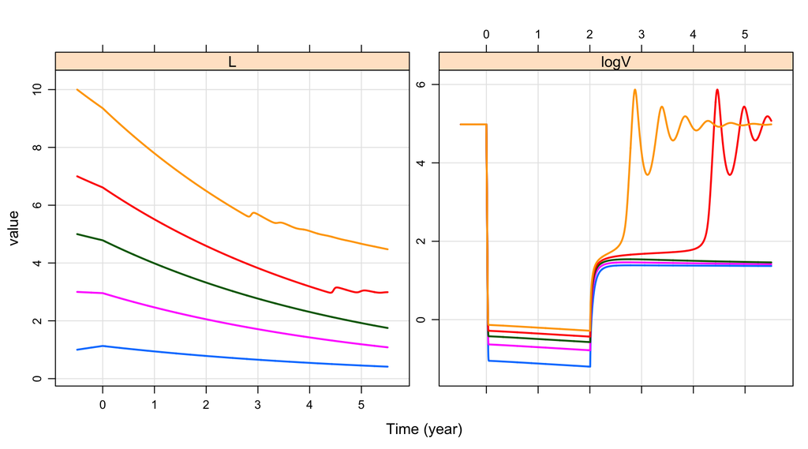

# About `mrgsolve`

- `R` package for simulation from ODE-based models
  - Free, OpenSource, GitHub, CRAN
- Language
  - Models written in `C++` inside model specification format
  - General purpose solver: `ODEPACK` / `DLSODA` (`FORTRAN`)
  - Simulation workflow in `R`
- Hierarchical (population) simulation
  - `ID`, $\eta$, $\varepsilon$
- Integrated PK functionaility
  - Bolus, infusion, `F`, `ALAG`, `SS` etc, handled under the hood
  - 1- and 2-cmt PK models in closed-form
- Extensible using `R`, `C++`, `Rcpp`, `boost`, `RcppArmadillo`
- `R` is it’s natural habitat

# `mrgsolve` started as `QSP` modeling tool

- Motivation: large bone/mineral homeostatsis model (CaBone)
- History using
  - Berkeley Madonna
  - WinBUGS
  - NONMEM (attempted)
- 2010: write `R` front end to `deSolve`
- 2012: write `C++` interface to `DLSODA`
- Develop dosing / event capability
- More recently, expose functionality provided by
  - `Rcpp` - vectors, matrices, functions, environments, random numbers
  - `boost` - numerical tools in `C++`
  - users’ own `C++` code (functions, data structures, classes)
- Translator from `SBML` to `mrgsolve` using `R` bindings to `libSBML`

# Orientation

- https://CRAN.R-project.org/package=mrgsolve
- GitHub site: https://github.com/metrumresearchgroup/mrgsolve
- mrgsolve website: https://mrgsolve.github.io
- User Guide: https://mrgsolve.github.io/user_guide

# What we will cover today

1. Three basic workflows
2. Loading the model into R
3. Event objects
4. Data sets
5. Model specification - code together
6. This and that
7. Applied examples
8. Whatever you ask about

### Emphasis is on getting you running your own simulations today.